# Asymptotic PEM Identification - Exercises

Table of Contents

Exercise 1 - Asymptotic Identification of an AR(2) Process with as a Model an AR(1) process Solution Initialization and Variables Declaration The Process The Prediction Error The Asymptotic Cost Functional The Minimum of the Cost The Model White Noise The Prediction Error Exercise 2 - Asymptotic Identification of a Process with an Exogenous Constant Input Solution - First Scenario The Minimum of the Cost The Prediction Error Solution - Second Scenario The Minimum of the Cost Exercise 3 - Asymptotic Identification of an AR(1) and an ARMA(1, 1) Process using an AR(1) Process as Model Solution The Asymptotic Cost Functional Scenario (a): the Process to be Identified is an AR(1) Process Scenario (b): the Process to be Identified is an ARMA(1, 1) Process

## Exercise 1 - Asymptotic Identification of an AR(2) Process with as a Model an AR(1) process

Given the stationary stochastic process 𝒮

$\mathcal{S}:\quad y(t) = \displaystyle a^{o}\,y(t-2)+e(t) \qquad e(\cdot) \sim \text{WN}\left(0,\,\lambda^2_{e})$

let's identify it using the model ℳ

$\mathcal{M}:\qquad y(t) = a\,y(t-1)+\eta(t) \qquad \eta(\cdot) \sim \text{WN}\left(0,\,\lambda^2_{\eta}\right)$

Determine the asymptotic solution

$\displaystyle \lim_{N \to \infty}\hat{a}(N) = \text{?}$

$\hat{\lambda}^2_{\eta}(N) \underset{N \to \infty}{\longrightarrow} \text{?}$

### Solution

Using the model ℳ let's determine the expression of the optimal 1-step predictor, fed by the data:

$\hat{y}\left(t\vert t-1\right) = a \,y(t-1)$

and evaluate the prediction error

$\epsilon(t) = y(t)-\hat{y}\left(t\vert t-1\right) = \big[a^{o}\,y(t-2) +e(t) -a\,y(t-1) \big]$

The asymptotic cost functional to be minimised is

$\bar{J}\left(\vartheta \right) = \text{E} \big\{ \left[\epsilon(t) \right]^2\big\} = \text{E} \big\{ \left[ y(t)-\hat{y}\left(t \vert t-1 \right)\right]^2 \big\}$

#### Initialization and Variables Declaration

```matlab
clear
close all
clc

sympref('HeavisideAtOrigin', 1); % the usual settings for the Symbolic Toolbox

syms a_o a % the symbolic parameters respectively of the process S and the model M

assume(a_o < 1);      % the process S is a stationary AR(2) process
assumeAlso(a_o > -1); % the paramenter a^o MUST obey to abs(a^o) <1
assumptions(a_o)
```

ans =

```matlab
syms lambda2_e lambda2_eta % the variances of the process white noise e(t) and the model noise eta(t)

syms y_t y_t1 y_t2 % symbolic variables for y(t), y(t-1) and y(t-2)

syms e_t eta_t % the white noises in the process S and the modeel M
```

#### The Process

The process 𝒮 difference equation

```matlab
y_t = a_o*y_t2 + e_t
```

y_t =

#### The Prediction Error

The prediction error $\epsilon(t) = y(t)-\hat{y}\left(t\vert t-1\right)$:

```matlab
hat_y_t = a*y_t1
```

hat_y_t =

```matlab
epsilon_t = y_t - hat_y_t
```

epsilon_t =

```matlab
epsilon_t = collect(epsilon_t)
```

epsilon_t =

#### The Asymptotic Cost Functional

Now develop the square of the prediction error

```matlab
eps_sqr_t = expand(epsilon_t^2)
```

eps_sqr_t =

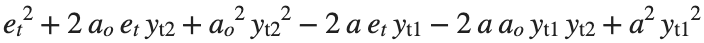

and evaluate the expected value $\text{E}\left[\epsilon^2(t) \right]$:

$\begin{array}{rcl} \text{E}\big[\epsilon^2(t) \big] &= & \left(a^{o}\right)^2\,\text{E}\left[ y^2\left(t-2\right) \right] + \text{E}\left[ e^2(t)\right]+ a^2\,\text{E}\left[y^2(t-1)\right] + \\ & & +2a^{o}\,\text{E}\left[ y(t-2)\cdot e(t) \right] - 2 a^{o}a\,\text{E}\left[ y(t-2)\cdot y(t-1) \right] -2a\,\text{E}\left[e(t) \cdot y(t-1) \right] \end{array}$

Remember, the following relationships hold true

$\text{var}\left[e(t)\right] = \lambda^2_e = \text{E}\left\{\left[e(t)\right]^2\right\}$

$\text{E}\left[ e(t)\cdot y(t-1)\right] = 0 \quad \text{E}\left[ e(t)\cdot y(t-2)\right] = 0$

$\text{E}\left[y(t)\right] = 0 \qquad \text{var}\left\{\left[y(t)\right]^2\right\} = \text{E}\left\{\left[y(t)\right]^2\right\} = \text{E}\left\{\left[y(t-1)\right]^2\right\} = \text{E}\left\{\left[y(t-2)\right]^2\right\} = \lambda^2_{yy}$

$\text{E}\left[ y(t-2) \cdot y(t-1) \right] = \gamma_{yy}(1) = 0$

Moreover, the variance $\lambda^2_{yy}$ takes the expression

$\begin{array}{rcl} \text{var}\left\{\left[y(t)\right]^2\right\} = \lambda^2_{yy} &=& \text{E} \left\{ \left(a^{o}\right)^2\, y^2(t-2) +e^2(t) +2a^{o}\,y(t-2)\,e(t) \right\} = \\ & =& \left(a^{o}\right)^2\,\lambda^2_{yy} + \lambda^2_ee + 2a^{o}\,\text{e}\left[ y(t-2) \cdot e(t) \right] = \left(a^{o}\right)^2\,\lambda^2_{yy} + \lambda^2_ee \quad \Longleftarrow \quad 2a^{o}\,\text{e}\left[ y(t-2) \cdot e(t) \right] = 0 \\ \left[1-\left(a^{o}\right)^2\right] \, \lambda^2_{yy} &= &\lambda^2_e \end{array}$

Thus

$\text{var}\left\{\left[y(t)\right]^2\right\} = \lambda^2_{yy} = \displaystyle \frac{1}{1-\left(a^{o}\right)^2} \, \lambda^2_e$

The asymptotic cost functional becomes

```matlab
bar_J = subs(eps_sqr_t, {e_t^2, e_t*y_t2, e_t*y_t1, y_t2*y_t1}, {lambda2_e, 0, 0, 0})
```

bar_J =

```matlab
var_y = lambda2_e/(1-a_o^2); % S is a peculiar AR(2) process

bar_J = subs(bar_J, {y_t2^2, y_t1^2}, {var_y, var_y})
```

bar_J =

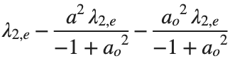

```matlab
bar_J = simplify(bar_J)
```

bar_J =

#### The Minimum of the Cost

Let's determine the optimal model of the family ℳ, minimising the cost $\bar J$

$\frac{d\, \bar{J}}{d a} = 0$

```matlab
jacJ = jacobian(bar_J, a)
```

jacJ =

```matlab
theta_o = solve(jacJ, a, 'ReturnConditions', true)
```

theta_o = struct with fields:

a: 0 parameters: [1×0 sym] conditions: symtrue

The optimal model (belonging to the familiy of models ℳ) is then an $AR(1)$ model with

```matlab
a_infty = theta_o.a
```

a_infty =

0

#### The Model White Noise

What about the variance of the white noise in the model ℳ?

Remember: generally, the variance of the noise corresponding to the optimal model (the model minimizing the cost functional J) is the minimum value of the cost functional associated with the optimal parameter.

Thus

$\hat{\lambda}^2_{\eta}(N) \underset{N \to \infty}{\longrightarrow} \bar{J}\left(\bar a\right) \qquad \bar{a} =\underset{a}{\mathrm{arg\,min}} \, \bar{J}(a)$

```matlab
bar_J
```

bar_J =

```matlab
lambda2_eta_infty = simplify(subs(bar_J, a, a_infty))
```

lambda2_eta_infty =

Note: the variance of the model ℳ noise η coincides witht the variance of the r.v. $y(y)$ of the process 𝒮

#### The Prediction Error

What about the optimal prediction error?

```matlab
hat_y_infty = a_infty*y_t1;

epsilon_infty = y_t - hat_y_infty
```

epsilon_infty =

The prediction error $\epsilon(t)$ coincides with the r.v. $y(t)$ of the process 𝒮. The prediction error is then also an $AR(2)$ process.

## Exercise 2 - Asymptotic Identification of a Process with an Exogenous Constant Input

Consider the stochastic process 𝒮 described by the following equations

$\mathcal{S} ; \quad \left\{ \begin{array}{rcl} y(t) &=& a^{o}\, u(t) + \eta(t) \\ \eta(t) &=& e(t)+ \displaystyle \frac{1}{2}\, e(t-1) \end{array} \right. \qquad a^{o} = 5$

where

$u(t) =1 \; , \quad \forall t \qquad \qquad e(\cdot) \sim \text{WN}\left( 0, 1\right)$

Let's identify the process with a model belonging to:

$\mathcal{M}: \qquad y(t) = a\,u(t) + \xi(t) \;,\quad \xi(\cdot) \sim \text{WN}(0,\,\lambda^2)$

- We want to use the least squares algorithm to estimate the model parameter $\hat{a}_N$: what does the estimate converge to, as the data used increases?

$\hat{a}_N \underset{N \to \infty}{\longrightarrow} \text{?}$

- What would change if

$e(\cdot) \sim \text{WN}\left(1,\,1\right) \quad \Longrightarrow \quad \hat{a}_N \underset{N \to \infty}{\longrightarrow} \text{?}$

### Solution - First Scenario

From model ℳ we obtain the expression of the 1-step predictor

$\hat{y}\left(t \vert t-1 \right) = a\,u(t) = a \quad \Longleftarrow \; u(t) =1 \; \forall t$

So the prediction error takes on the expression

$\epsilon(t) = y(t) - \hat{y}\left(t \vert t-1 \right) = \left(5-a\right) + \eta(t)$

The asymptotic cost functional to be minimised takes on the expression

$\bar{J}(a) = \text{E} \left\{ \left[ \left(5-a\right) + \eta(t) \right]^2 \right\}$

Moreover, when $e(\cdot) \sim \text{WN}\left( 0, 1\right)$

$\text{E}\left[ \eta(t) \right] = \text{E}\left[e(t) + \displaystyle \frac{1}{2}\,e(t-1) \right] = 0 \qquad \text{var}\left[\eta(t) \right] = \left(1^2+ \displaystyle \left(\frac{1}{2}\right)^2\right)\cdot \lambda^2_{e} = \displaystyle \frac{5}{4}$

```matlab
clear
close all
clc

syms a a_o

syms y_t1 eta_t

u = sym(1);
E_eta = sym(0);

var_Eta = sym(5/4);
```

The prediction error $\epsilon(t) = y(t)-\hat{y}\left(t\vert t-1\right)$ is:

```matlab
y_t = a_o*u + eta_t
```

y_t =

```matlab
hat_y = a*u;

epsilon_t = y_t - hat_y
```

epsilon_t =

```matlab
epsilon_t = collect(epsilon_t)
```

epsilon_t =

Now let's develop the square of the prediction error

```matlab
eps_sqr = expand(epsilon_t^2)
```

eps_sqr =

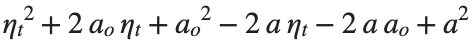

and evaluate the expected value. Remember, the following relationships hold true

$\text{var}\left[\eta(t)\right] = \frac{5}{4} = \text{E}\left\{\left[\eta(t)\right]^2\right\}$

$\text{E}\left[ \eta(t)\right] = 0$

Thus

```matlab
bar_J = subs(eps_sqr, {eta_t^2, eta_t}, {var_Eta, E_eta})
```

bar_J =

#### The Minimum of the Cost

Let's determine the optimal model of the family ℳ, minimising the cost $\bar J$

$\frac{\partial \bar{J}}{\partial \vartheta} = 0$

```matlab
jacJ = jacobian(bar_J, a)
```

jacJ =

```matlab
theta_o = solve(jacJ)
```

theta_o =

So

$\hat{a}_N \underset{N \to \infty}{\longrightarrow} a^{o}$

#### The Prediction Error

What about the optimal prediction error?

```matlab
hat_y_o = theta_o*u;

epsilon_o = y_t - hat_y_o
```

epsilon_o =

### Solution - Second Scenario

If $e(\cdot) \sim \text{WN}\left(1,\,1\right) \$ then

$\text{E}\left[ \eta(t) \right] = \text{E}\left[e(t) + \displaystyle \frac{1}{2}\,e(t-1) \right] = \frac{3}{2} \qquad \text{var}\left[\eta(t) \right] = \left(1^2+ \displaystyle \left(\frac{1}{2}\right)^2\right)\cdot \lambda^2_{e} = \displaystyle \frac{5}{4}$

Now develop the square of the prediction error

```matlab
E2_eta = sym(3/2);

eps_sqr = expand(epsilon_t^2)
```

eps_sqr =

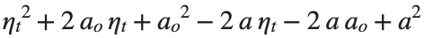

and evaluate the expected value. Remember, the following relationships hold true

$\text{E}\left\{\left[\eta(t)\right]^2\right\} = \text{var}\left[\eta(t)\right] + \big\{ \text{E}\left[\eta(t)\right]\big\}^2= \frac{5}{4} +\frac{9}{4} = \frac{7}{2}$

$\text{E}\left[ \eta(t)\right] = \frac{3}{2}$

Thus the asymptotic cost becomes

```matlab
Esquared_eta = sym(7/2);
bar_J2 = subs(eps_sqr, {eta_t^2, eta_t}, {Esquared_eta, E2_eta})
```

bar_J2 =

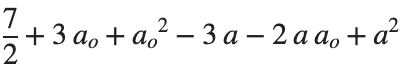

#### The Minimum of the Cost

Let's determine the optimal model of the family ℳ, minimising the cost $\bar J$

$\frac{\partial \bar{J}}{\partial \vartheta} = 0$

```matlab
jacJ2 = jacobian(bar_J2, a)
```

jacJ2 =

```matlab
theta_o2 = solve(jacJ2)
```

theta_o2 =

So

$\hat{a}_N \underset{N \to \infty}{\longrightarrow} \bar{a} = a^{o} + \frac{3}{2} \ne a^{o}$

## Exercise 3 - Asymptotic Identification of an AR(1) and an ARMA(1, 1) Process using an AR(1) Process as Model

N observations of the random variable $y(t)$ of a stationary stochastic process 𝒮 are available.

$\Big\{ y(1),\, y(2),\, y(3),\, \ldots y(N) \Big\}$

As a family ℳ of models for the description of the stochastic process 𝒮 we choose

$\mathcal{M}: \quad y(t) = a\,y(t-1) + e(t) \quad e(\cdot ) \sim \text{WN}\left(0,\, \lambda^2_e\right)$

With $\hat{a}_N$ we denote the least-squares estimate of the parameter a in the model ℳ.

To which value does the estimate $\hat{a}_N$ tend when the number of observations N increases? $\hat{a}_N \underset{N \to \infty}{\longrightarrow} \text{?}$

Let us consider two possible scenarios for the process 𝒮:

a) an $AR(1)$ stationary process: $\mathcal{S}_{(a)} \Longrightarrow y(t) = \displaystyle \frac{3}{10} y(t-1) + \xi(t) \quad \xi(\cdot ) \sim \text{WN}\left(0,\, 1\right)$

b) an $ARMA(1,\,1)$ stationary process: $\mathcal{S}_{(b)} \Longrightarrow y(t) = \displaystyle \frac{3}{10} y(t-1) + \xi(t) +\frac{1}{2}\,\xi(t-1) \quad \xi(\cdot ) \sim \text{WN}\left(0,\,1\right)$

### Solution

```matlab
clear
close all
clc

syms a  % the parameter of the model M

syms y_t y_t1 y_t2  % the symbolic variables for the r.v. y(t), y(t-1) and y(t-2)
syms xi_t xi_t1 % the symbolic variables for the samples of the white noise xi(t) and xi(t-1)
```

#### The Asymptotic Cost Functional

Using the model ℳ we obtain the one-step forward predictor, fed by the observed data

$\hat{y}\left(t \vert t-1 \right) = a\, y(t-1)$

```matlab
hat_yt = a*y_t1;
```

When $N \to \infty$ the estimate $\hat{a}_{N}$ converges to

$\hat{a}_{N} \underset{N \to \infty}{\longrightarrow} \underset{a}{\mathrm{arg\,min}} \, \bar{J}(a)$

where the asymptotic cost functional takes on the expression

$\begin{array}{rcl} \bar{J}\left(a\right) &=& \text{E} \left\{ \left[ y(t) - \hat{y}\left( t \vert t-1 \right) \right]^2 \right\} \quad \Longleftarrow \quad \hat{y}\left(t \vert t-1 \right) = a\, y(t-1)\\ &=& \text{E} \left\{ \left[ y(t)\right]^2 \right\} + a^2\,\text{E} \left\{ \left[ y(t-1) \right]^2 \right\} - 2a\,\text{E} \left\{y(t) \cdot y(t-1) \right\} \end{array}$

```matlab
epsilon_t = y_t - hat_yt;
bar_J = expand(epsilon_t^2);
bar_J
```

bar_J =

In both the considered scenarios it holds that

$\text{E}\left[y(t)\right] = 0$

Moreover, both the processes $\mathcal{S}_{(a)}$ and $\mathcal{S}_{(b)}$ are stationary stochastic processes. Thus

$\text{var} \left[ y(t)\right] = \gamma_{yy}(0) = \text{E}\big\{ \left[ y(t) \right]^2 \big\} = \text{E}\big\{ \left[ y(t-1) \right]^2 \big\}$

$\begin{array}{rcl} \bar{J}\left(a\right) &=& \text{E} \big\{ \left[ y(t) \right]^2 \big\} + a^2\, \text{E} \big\{ \left[ y(t-1) \right]^2 \big\} -2a\,\text{E}\left\{ y(t) \cdot y(t-1) \right\} = \\ &= & \left(1+a^2 \right)\cdot \gamma_{yy}(0) - 2a\cdot \gamma_{yy}(1) \end{array}$

```matlab
syms gamma_0 gamma_1 % variance of the r.v. y(t) and the value of the autocorrelation function gamma_y(1)
bar_J = subs(bar_J, {y_t^2, y_t1^2, y_t*y_t1}, {gamma_0, gamma_0, gamma_1});
```

The minimum (optimal) value of the cost is obtained at

$\displaystyle \frac{d\,\bar{J}}{d a} = 0 \quad \Longrightarrow \quad 2a\,\gamma_{yy}(0) - 2\,\gamma_{yy}(1) = 0$

Solving the equation, we get the value $\bar a$ of the parameter minimizing the cost

$\bar{a} = \displaystyle \frac{\gamma_{yy}(1)}{\gamma_{yy}(0)$

Obviously, in both cases (a) and (b), the values of $\gamma_{yy}(0)$ and $\gamma_{yy}(1)$ must be determined.

```matlab
jacJ = jacobian(bar_J, a);
bar_a = solve(jacJ, a)
```

bar_a =

#### Scenario (a): the Process to be Identified is an AR(1) Process

Evaluating $\gamma_{yy}(0)$ and $\gamma_{yy}(1)$ we get

$\gamma_{yy}(0) = \text{var} \left[ y(t) \right]$

$\begin{array}{rcl} \gamma_{yy}(1) &=& \text{E} \left[ y(t) \cdot y(t-1) \right] = \\ &=& \text{E} \left\{ \left[ \displaystyle \frac{3}{10} \,y(t-1) +\xi(t) \right] \cdot y(t-1) \right\} = \\ &=& \displaystyle \frac{3}{10} \, \gamma_{yy}(0) \end{array}$

Thus, in the scenario with $\mathcal{S}_{(a)}$ we get

$\hat{a}_N \underset{N \to \infty}{\longrightarrow} \bar{a} = \displaystyle \frac{3}{10}$

```matlab
syms gamma_0a % the variance in the scenario (a)
gamma_1a = 3*gamma_0a/10;
bar_a_Sa = subs(bar_a, {gamma_0, gamma_1}, {gamma_0a, gamma_1a})
```

bar_a_Sa =

#### Scenario (b): the Process to be Identified is an ARMA(1, 1) Process

In this scenario we get

$\begin{array}{rcl} \gamma_{yy}(0) &=& \text{E}\left\{\left[y(t)\right]^2 \right\} = \\ &=& \displaystyle \frac{9}{100}\, \text{E}\big\{\left[y(t-1)\right]^2 \big\} + \text{E} \big\{ \left[ \xi(t) \right]^2 \big\} + \frac{1}{4} \text{E} \big\{ \left[\xi(t-1)\right]^2 \big\} + \\ & & +2\cdot \frac{3}{10}\, \text{E} \big\{ y(t-1) \cdot \xi(t) \big\} + 2\cdot \frac{3}{10} \cdot \frac{1}{2} \, \text{E} \big\{ y(t-1) \cdot \xi(t-1) \big\} + 2\cdot \frac{1}{2}\, \text{E} \big\{ \xi(t) \cdot \xi(t-1) \big\} \end{array}$

```matlab
y_t = (3/10)* y_t1 + xi_t + (1/2)*xi_t1
```

y_t =

```matlab
gamma_0b = expand(y_t^2)
```

gamma_0b =

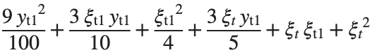

Remember, the following relationships hold true

$\text{var}\left[ \xi(t) \right] = \text{E} \left[ \xi^2(t) \right] = \text{E} \left[ \xi^2(t-1) \right] = 1$

$\text{E} \big\{ y(t-1) \cdot \xi(t) \big\} = 0 \qquad \text{E} \big\{ \xi(t) \cdot \xi(t-1) \big\} = 0$

$\text{E} \big\{ y(t-1) \cdot \xi(t-1) \big\} = \text{E} \big\{ \left[\xi(t-1) \right]^2 \big\} = \text{var} \left[ \xi(t) \right] = 1$

So

```matlab
var_xi = sym(1);

gamma_0b = subs(gamma_0b, {xi_t^2, xi_t1^2, xi_t*y_t1, xi_t*xi_t1, y_t1*xi_t1}, ...
                 {var_xi, var_xi, 0, 0, var_xi})
```

gamma_0b =

Then $\left( 1 - \displaystyle \frac{9}{100} \right) \, \gamma_{yy}(0) = \frac{31}{20} \quad \Longrightarrow \quad \gamma_{yy}(0) = \frac{155}{91}$

```matlab
syms gamma0
Eq_gamma0 = gamma0 - subs(gamma_0b, y_t1^2, gamma0);
bar_gamma0b = solve(Eq_gamma0, gamma0)
```

bar_gamma0b =

Finally, the term $\gamma_{yy}(1)$ becomes

$\begin{array}{rcl} \gamma_{yy}(1) &=& \text{E}\big\{ y(t) \cdot y(t-1) \big\} = \\ &= & \frac{3}{10} \, \text{E} \big\{ \left[y(t-1)\right]^2 \big\} + \text{E} \left[ \xi(t) \cdot y(t-1) \right] + \frac{1}{2}\, \text{E} \big\{ y(t-1) \cdot \xi(t-1) \big\} = \\ & = & \frac{3}{10}\, \gamma_{yy}(0) + 0 + \frac{1}{2} \cdot 1 = \frac{92}{91} \end{array}$

```matlab
gamma_1b = expand(y_t*y_t1)
```

gamma_1b =

```matlab
bar_gamma_1b = subs(gamma_1b, {y_t1^2, xi_t1*y_t1, xi_t*y_t1}, {bar_gamma0b, var_xi, 0})
```

bar_gamma_1b =

Thus, in the scenario with $\mathcal{S}_{(b)}$ we get

$\hat{a}_N \underset{N \to \infty}{\longrightarrow} \bar{a} = \displaystyle \frac{92}{155}$

```matlab
bar_a_Sb = bar_gamma_1b/bar_gamma0b
```

bar_a_Sb =